# CPUE Reineta 2022

Selim Musleh

2022-06-13

# Resumen datos de enmalle para Reineta 2022

## Concideraciones de la base de datos:

- Enmalle empieza con datos desde el 2004
- *COD_ESPECIE 6*: Información proviene de encuestas en puerto
- *PESO* Columna más completa que la de abajo
- *PESO_TOTAL_CAPTURA* no tan completa
- *PROFUNDIDAD_LM_ENM* y *PROFUNDIDAD* complementan la data de Profundidad. La profundidad de operaciones usando enmalle no debería superar loas 50 m
- *HORA_DE_REPOSO*: los dos primeros dígitos corresponden a horas y los dos últimos a minutos. Muy rara vez las redes quedan caladas de un día para otro.
- Pesca ocurre en una zona entre lebu y bucalemu o sur de san antonio
- Columnas que contienen información relacionada a Esfierzo
  - *LONGITUD_RED*: Usada para cpue en seguimiento (Se puede alargar o acortar las redes entre operaciones). Largo de Red puede ser buena medida de esfuerzo (ellos usan kg/m, metro lineal de red)
  - *TAMANIO_MALLA*: Está bastante estandar en promedio 7’’, pero se mueve entre 5 y 8.
  - *NUMERO_PANIOS*: Paño no es una medida estandar usar en cpue
  - *HORA_DE_REPOSO*: Podría ser un componente del esfuerzo junto a *LONGITUD_RED*

# Tablas

Tablas con número de registro pro año. También está creada la tabla por año y por mes, pero no la presento por ahora.

Data por columna por año

| year | PESO | Hora_reposo | LONGITUD_RED | TAMANIO_MALLA | NUMERO_PANIOS | prof |
| --- | --- | --- | --- | --- | --- | --- |
| 2004 | 64 | 62 | 63 | 63 | 64 | 2 |
| 2005 | 26 | 21 | 26 | 26 | 26 | 1 |
| 2006 | 21 | 20 | 21 | 20 | 21 | 20 |
| 2007 | 72 | 71 | 70 | 72 | 71 | 72 |
| 2008 | 162 | 162 | 159 | 159 | 159 | 145 |
| 2009 | 188 | 178 | 185 | 188 | 188 | 155 |
| 2010 | 150 | 150 | 150 | 150 | 150 | 147 |
| 2011 | 488 | 485 | 484 | 486 | 486 | 481 |
| 2012 | 399 | 398 | 398 | 389 | 396 | 398 |
| 2013 | 265 | 259 | 264 | 263 | 264 | 241 |
| 2014 | 261 | 225 | 261 | 260 | 261 | 243 |
| 2015 | 252 | 241 | 252 | 252 | 252 | 247 |
| 2016 | 147 | 134 | 147 | 147 | 147 | 144 |
| 2017 | 169 | 137 | 169 | 169 | 169 | 148 |
| 2018 | 239 | 230 | 239 | 239 | 239 | 218 |
| 2019 | 366 | 351 | 366 | 366 | 366 | 244 |
| 2020 | 192 | 185 | 192 | 192 | 192 | 191 |
| 2021 | 771 | 768 | 762 | 771 | 771 | 765 |
| 2022 | 309 | 293 | 309 | 308 | 309 | 304 |

Valor acumulado por variable por año

Data por columna por año

| year | PESO | Hora_reposo | LONGITUD_RED | TAMANIO_MALLA | NUMERO_PANIOS | prof |
| --- | --- | --- | --- | --- | --- | --- |
| 2004 | 18827 | 249.4 | 28392 | 1132 | 670 | 10 |
| 2005 | 16247 | 70.6 | 15959 | 194 | 382 | 90 |
| 2006 | 38474 | 402.8 | 24450 | 130 | 453 | 358 |
| 2007 | 135180 | 536.6 | 114691 | 503 | 1510 | 1241 |
| 2008 | 420620 | 2585.6 | 76085 | 1103 | 3552 | 2129 |
| 2009 | 325543 | 1889.2 | 188084 | 1312 | 4143 | 3561 |
| 2010 | 209766 | 1218.6 | 168352 | 932 | 3411 | 2792 |
| 2011 | 1681457 | 3482.8 | 773530 | 3228 | 12529 | 5647 |
| 2012 | 722681 | 2929.0 | 446111 | 2540 | 9402 | 6651 |
| 2013 | 485184 | 2075.4 | 351434 | 1778 | 7128 | 3789 |
| 2014 | 673906 | 2391.2 | 385494 | 1920 | 7471 | 738735 |
| 2015 | 434904 | 2798.6 | 331329 | 1642 | 7126 | 4209 |
| 2016 | 325677 | 1127.2 | 206310 | 1007 | 4005 | 1269 |
| 2017 | 251040 | 865.1 | 255837 | 1155 | 5392 | 1297 |
| 2018 | 302419 | 1432.3 | 364474 | 1602 | 7337 | 1466 |
| 2019 | 731754 | 2459.0 | 584250 | 2420 | 11459 | 3731 |
| 2020 | 485049 | 1051.8 | 324014 | 1298 | 5878 | 1341 |
| 2021 | 1069721 | 4658.0 | 1048049 | 5158 | 21620 | 7917 |
| 2022 | 747933 | 1838.0 | 441288 | 2140 | 7860 | 1320 |

Gráfico para valor acumulado por variable y por año

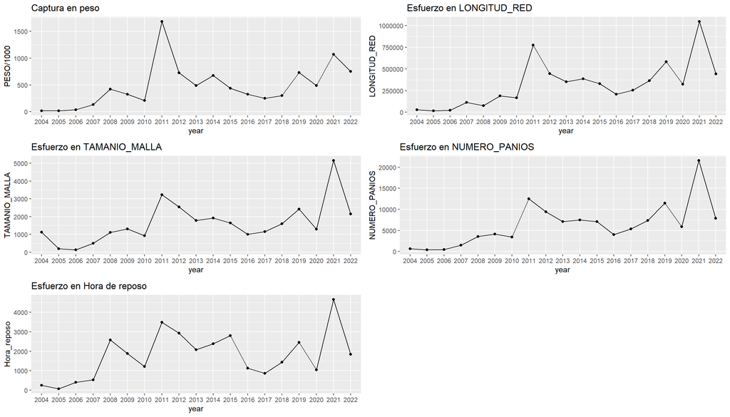

Valor acumulado para captura en peso y esfuerzo en hora de reposo del enmalle por año

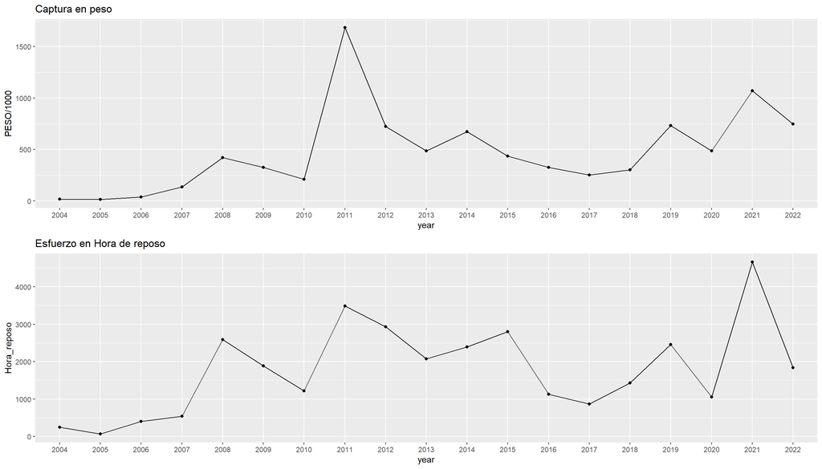

Gráfico de la Variabilidad de las dos potenciales medidas de esfuerzo:

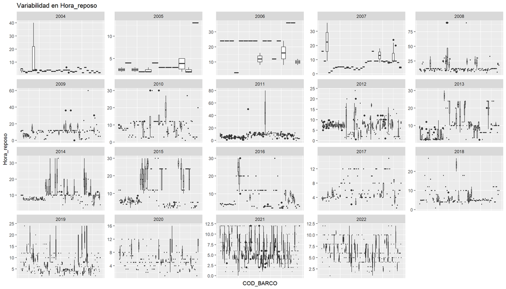

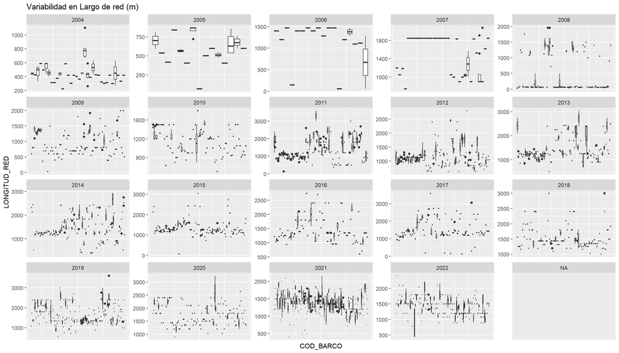

# Filtrado de datos

Para el filtrado de datos tomé en cuenta la información provista por Jorge Satler un la reunión del 8-06-2022 y algunas caractarísticas de los datos, lo segundo principalmente para remover dato extremos.

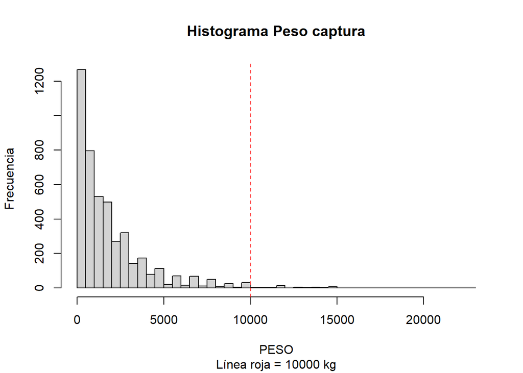

```r
#capturas PESO
hist(reineta_2022$PESO, breaks = 40,
     main = "Histograma Peso captura", sub="Línea roja = 10000 kg",
     xlab = "PESO", ylab="Frecuencia")
abline(v=10000, col="red", lty=2)
```

```r
filtrado_1<-subset(reineta_2022, reineta_2022$PESO <= 10000)
```

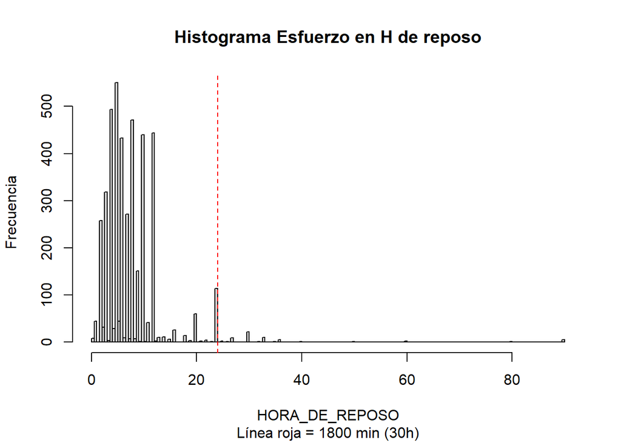

```r
#esfuerzo HORA_DE_REPOSO
hist(reineta_2022$Hora_reposo, breaks = 200,
     main = "Histograma Esfuerzo en H de reposo", sub="Línea roja = 1800 min (30h)",
     xlab = "HORA_DE_REPOSO", ylab="Frecuencia")
abline(v=24, col="red", lty=2)
```

```r
filtrado_2<-subset(filtrado_1, filtrado_1$Hora_reposo <= 24)
```

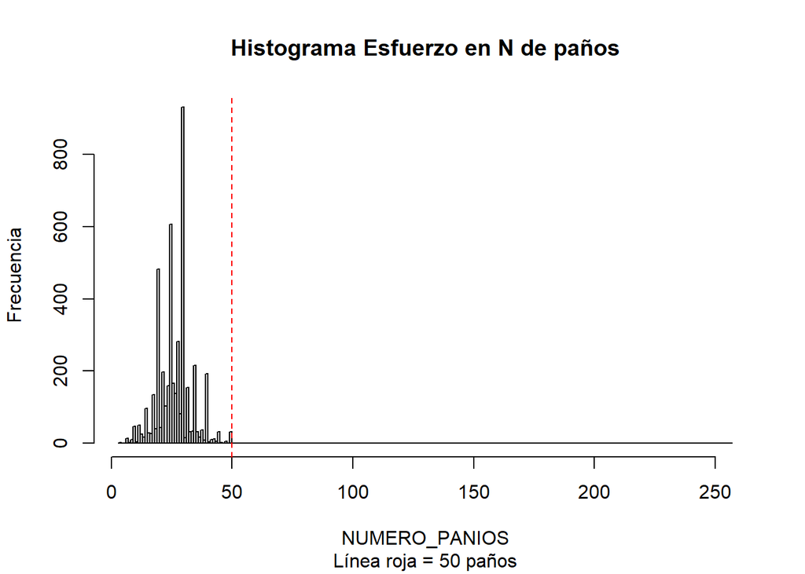

```r
#esfuerzo NUMERO_PANIOS
hist(reineta_2022$NUMERO_PANIOS, breaks = 200,
     main = "Histograma Esfuerzo en N de paños", sub="Línea roja = 50 paños",
     xlab = "NUMERO_PANIOS", ylab="Frecuencia")
abline(v=50, col="red", lty=2)
```

```r
filtrado_3<-subset(filtrado_2, filtrado_2$NUMERO_PANIOS <= 50)
```

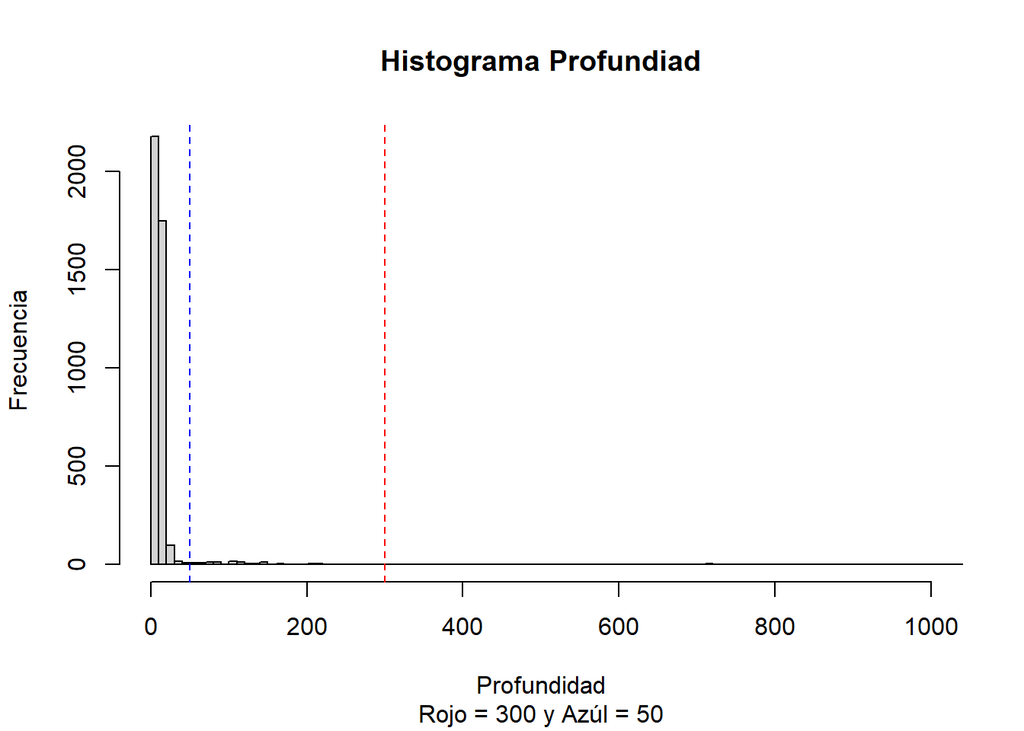

```r
#PROFUNDIDAD
hist(reineta_2022$prof, xlim = c(0, 1000), breaks = 100000,
     main = "Histograma Profundiad", sub="Rojo = 300 y Azúl = 50",
     xlab = "Profundidad", ylab="Frecuencia")
abline(v=300, col="red", lty=2)
abline(v=50, col="blue", lty=2)
```

```r
filtrado_4<-subset(filtrado_3, filtrado_3$prof <= 50) #50 m
```

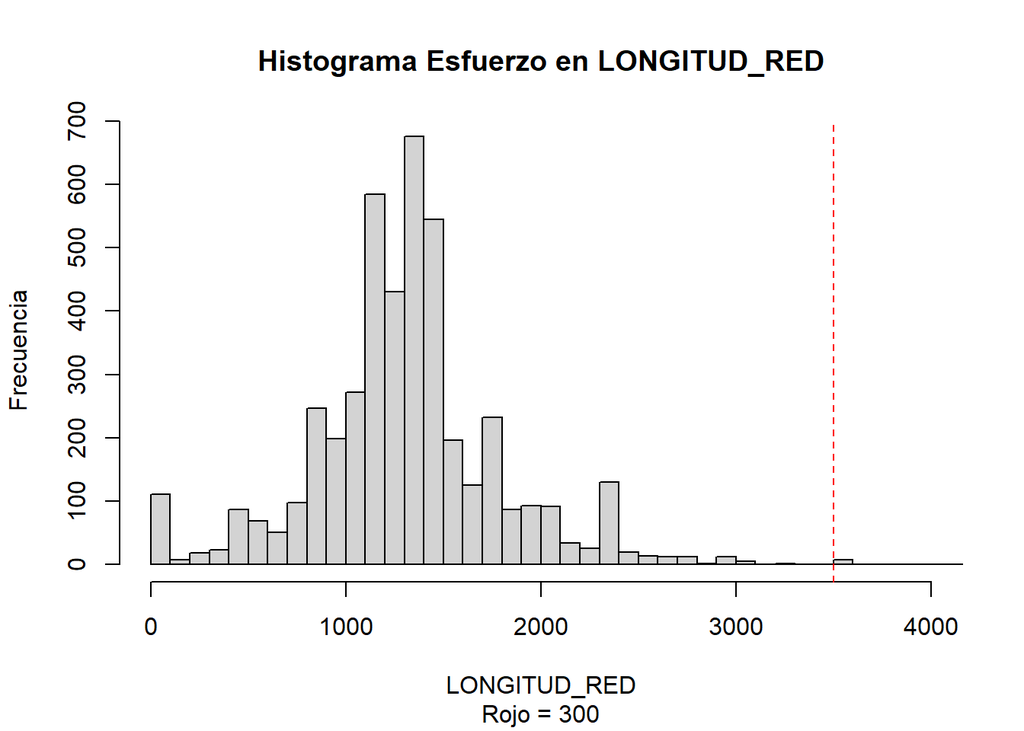

```r
#esfuerzo LONGITUD_RED
hist(reineta_2022$LONGITUD_RED, xlim = c(0, 4000), breaks = 1000,
     main = "Histograma Esfuerzo en LONGITUD_RED", sub="Rojo = 300",
     xlab = "LONGITUD_RED", ylab="Frecuencia")
abline(v=3500, col="red", lty=2)
```

```r
filtrado_5<-subset(filtrado_4, filtrado_4$LONGITUD_RED <= 3500)
```

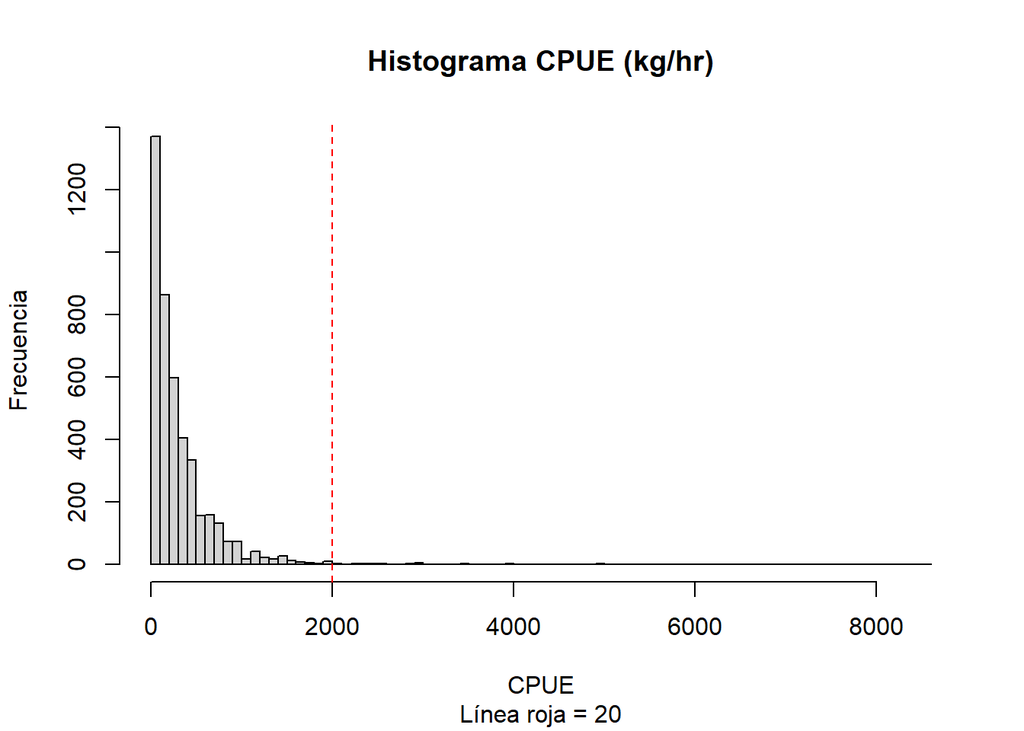

```r
#esfuerzo CPUE horas de reposo
hist(reineta_2022$cpue_hr, breaks=100,
     main = "Histograma CPUE (kg/hr)", sub="Línea roja = 20",
     xlab = "CPUE", ylab="Frecuencia")
abline(v=2000, col="red", lty=2)
```

```r
filtrado_6<-subset(filtrado_5, filtrado_5$cpue_hr <= 2000)
```

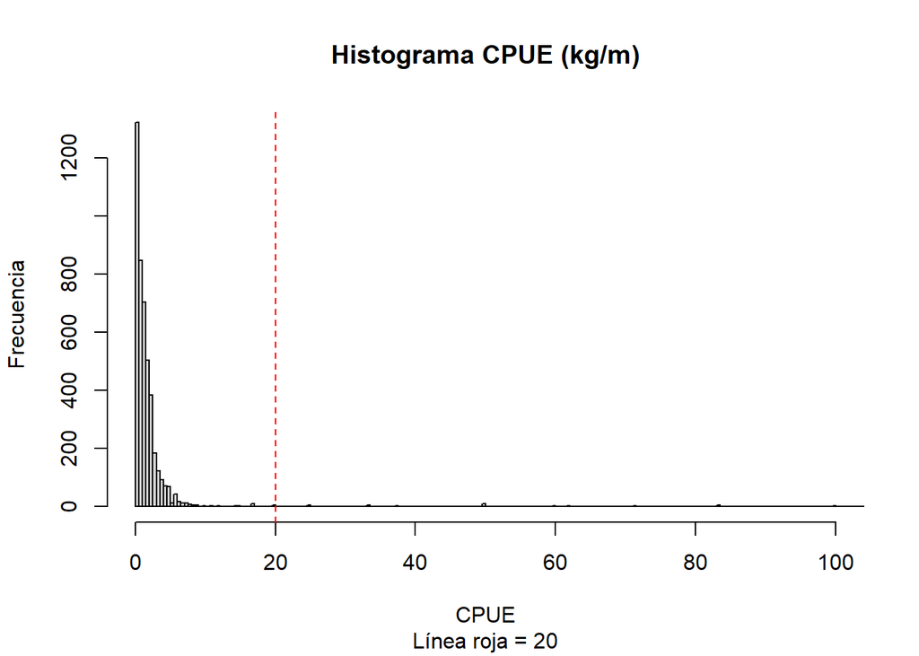

```r
#esfuerzo CPUE Largo de red
hist(reineta_2022$cpue_ml, breaks=1000, xlim=c(0, 100),
     main = "Histograma CPUE (kg/m)", sub="Línea roja = 20",
     xlab = "CPUE", ylab="Frecuencia")
abline(v=20, col="red", lty=2)
```

```r
filtrado_7<-subset(filtrado_6, filtrado_6$cpue_ml <= 20)
```

# Reporte de los filtros

```r
print(paste("Base de datos inicial=",dim(reineta_2022)[1]))
```

```
## [1] "Base de datos inicial= 4541"
```

```r
print(paste("Filtro PESO <= 10000",dim(filtrado_1)[1]))
```

```
## [1] "Filtro PESO <= 10000 4494"
```

```r
print(paste("Filtro HORA_DE_REPOSO <= 24h=",dim(filtrado_2)[1]))
```

```
## [1] "Filtro HORA_DE_REPOSO <= 24h= 4263"
```

```r
print(paste("Filtro NUMERO_PANIOS <= 50)=",dim(filtrado_3)[1]))
```

```
## [1] "Filtro NUMERO_PANIOS <= 50)= 4258"
```

```r
print(paste("Filtro prof <= 50 m=",dim(filtrado_4)[1]))
```

```
## [1] "Filtro prof <= 50 m= 3843"
```

```r
print(paste("Filtro LONGITUD_RED <= 3500 m=",dim(filtrado_5)[1]))
```

```
## [1] "Filtro LONGITUD_RED <= 3500 m= 3829"
```

```r
print(paste("Filtro cpue_hr <= 2000 kg/hr=",dim(filtrado_6)[1]))
```

```
## [1] "Filtro cpue_hr <= 2000 kg/hr= 3799"
```

```r
print(paste("Filtro cpue_ml <= 20 kg/m=",dim(filtrado_7)[1]))
```

```
## [1] "Filtro cpue_ml <= 20 kg/m= 3736"
```

El año 2004 quedó con solo un dato, así que también lo removí del análisis

```r
filtrado_8<-subset(filtrado_7, filtrado_7$year != 2004) # quedaba un sólo registro del 2004
```

Data por columna por año

| year | PESO | Hora_reposo | LONGITUD_RED | cpue_hr | cpue_ml | prof | month |
| --- | --- | --- | --- | --- | --- | --- | --- |
| 2006 | 17 | 17 | 17 | 17 | 17 | 17 | 17 |
| 2007 | 67 | 67 | 67 | 67 | 67 | 67 | 67 |
| 2008 | 65 | 65 | 65 | 65 | 65 | 65 | 65 |
| 2009 | 137 | 137 | 137 | 137 | 137 | 137 | 137 |
| 2010 | 129 | 129 | 129 | 129 | 129 | 129 | 129 |
| 2011 | 435 | 435 | 435 | 435 | 435 | 435 | 435 |
| 2012 | 365 | 365 | 365 | 365 | 365 | 365 | 365 |
| 2013 | 230 | 230 | 230 | 230 | 230 | 230 | 230 |
| 2014 | 204 | 204 | 204 | 204 | 204 | 204 | 204 |
| 2015 | 213 | 213 | 213 | 213 | 213 | 213 | 213 |
| 2016 | 125 | 125 | 125 | 125 | 125 | 125 | 125 |
| 2017 | 116 | 116 | 116 | 116 | 116 | 116 | 116 |
| 2018 | 214 | 214 | 214 | 214 | 214 | 214 | 214 |
| 2019 | 224 | 224 | 224 | 224 | 224 | 224 | 224 |
| 2020 | 175 | 175 | 175 | 175 | 175 | 175 | 175 |
| 2021 | 736 | 736 | 736 | 736 | 736 | 736 | 736 |
| 2022 | 283 | 283 | 283 | 283 | 283 | 283 | 283 |

# Gráficos finales

Caputra, esfuerzo y CPUE basados en horas de reposo

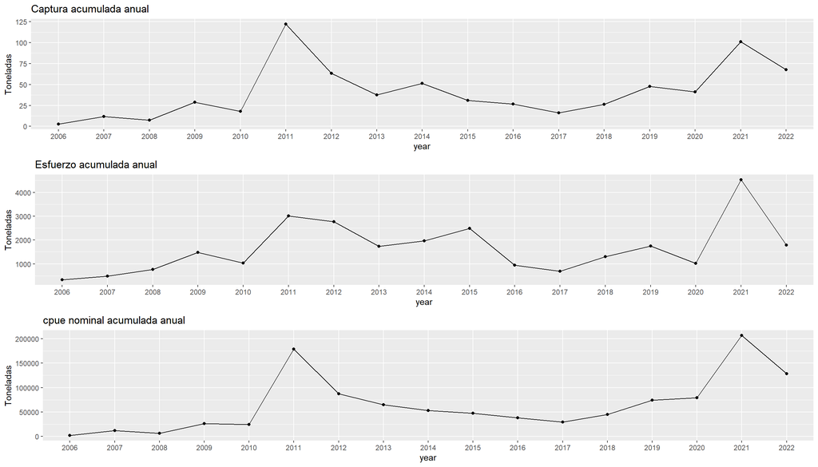

Caputra, esfuerzo y CPUE basados en largo de red

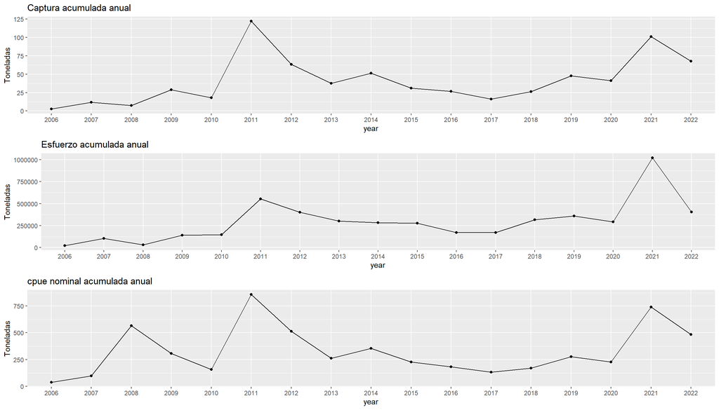

# Evaluando CPUE vs Capturas

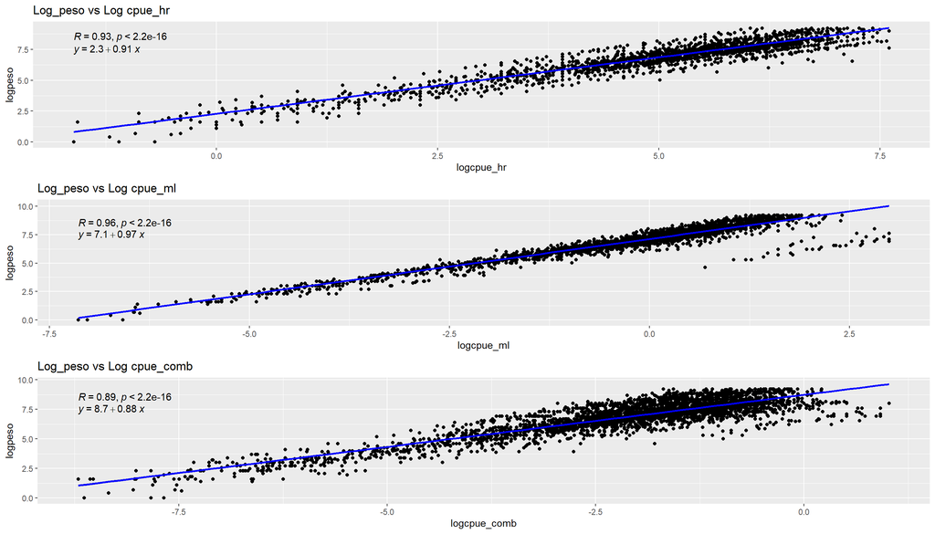

# Propuestas de estandarización

Modelo presentado explroando las relaciones usando un GAM con los siguientes argumentos: `gam(logcpue_ml ~ f_year + trimestre + s(LATITUD, LONGITUD) + COD_BARCO` El valor de CPUE usado es el la captura dividido por esfuerzo como metro lineal de red, porque tenía el mejor ajuste en la regresión de captura vs cpue.

```
## [1] "Modelo logcpue_ml"
```

```
## [1] "Deviance explained: 0.56%"
```

# Uniendo datos de bitácoras con maestro naves

La idea es poder agregar factores relacionados a las características de las embaciones para hacer más pruebas en la estandarización de la cpue

Data por columna por año

| f_year | logpeso | logcpue_hr | logcpue_ml | logcpue_comb | cpue_hr | cpue_ml | f_month | trimestre | COD_BARCO | LATITUD | LONGITUD | Eslora | Manga | Punta | Potencia | TRG |
| --- | --- | --- | --- | --- | --- | --- | --- | --- | --- | --- | --- | --- | --- | --- | --- | --- |
| 2006 | 17 | 17 | 17 | 17 | 17 | 17 | 17 | 17 | 17 | 17 | 17 | 16 | 16 | 16 | 15 | 16 |
| 2007 | 67 | 67 | 67 | 67 | 67 | 67 | 67 | 67 | 67 | 65 | 66 | 33 | 33 | 33 | 24 | 33 |
| 2008 | 65 | 65 | 65 | 65 | 65 | 65 | 65 | 65 | 65 | 65 | 65 | 60 | 60 | 60 | 49 | 56 |
| 2009 | 137 | 137 | 137 | 137 | 137 | 137 | 137 | 137 | 137 | 137 | 137 | 122 | 122 | 122 | 111 | 109 |
| 2010 | 129 | 129 | 129 | 129 | 129 | 129 | 129 | 129 | 129 | 92 | 92 | 101 | 101 | 101 | 80 | 76 |
| 2011 | 435 | 435 | 435 | 435 | 435 | 435 | 435 | 435 | 435 | 419 | 419 | 432 | 432 | 431 | 414 | 275 |
| 2012 | 365 | 365 | 365 | 365 | 365 | 365 | 365 | 365 | 365 | 352 | 351 | 362 | 362 | 362 | 328 | 233 |
| 2013 | 230 | 230 | 230 | 230 | 230 | 230 | 230 | 230 | 230 | 230 | 230 | 230 | 230 | 230 | 212 | 127 |
| 2014 | 204 | 204 | 204 | 204 | 204 | 204 | 204 | 204 | 204 | 204 | 204 | 201 | 201 | 201 | 184 | 150 |
| 2015 | 213 | 213 | 213 | 213 | 213 | 213 | 213 | 213 | 213 | 213 | 213 | 213 | 213 | 213 | 190 | 137 |
| 2016 | 125 | 125 | 125 | 125 | 125 | 125 | 125 | 125 | 125 | 122 | 122 | 125 | 125 | 125 | 105 | 105 |
| 2017 | 116 | 116 | 116 | 116 | 116 | 116 | 116 | 116 | 116 | 115 | 115 | 116 | 116 | 116 | 102 | 90 |
| 2018 | 214 | 214 | 214 | 214 | 214 | 214 | 214 | 214 | 214 | 214 | 214 | 212 | 212 | 212 | 179 | 194 |
| 2019 | 224 | 224 | 224 | 224 | 224 | 224 | 224 | 224 | 224 | 224 | 224 | 220 | 220 | 220 | 205 | 212 |
| 2020 | 175 | 175 | 175 | 175 | 175 | 175 | 175 | 175 | 175 | 175 | 175 | 175 | 175 | 175 | 162 | 168 |
| 2021 | 735 | 735 | 735 | 735 | 735 | 735 | 735 | 735 | 735 | 735 | 735 | 730 | 730 | 729 | 668 | 711 |
| 2022 | 283 | 283 | 283 | 283 | 283 | 283 | 283 | 283 | 283 | 283 | 283 | 282 | 282 | 281 | 268 | 273 |